# Practical Machine Learning - Course Project

Maurizio Scibilia

31/01/2020

## Overview

Using devices such as Jawbone Up, Nike FuelBand, and Fitbit it is now possible to collect a large amount of data about personal activity relatively inexpensively. These type of devices are part of the quantified self movement – a group of enthusiasts who take measurements about themselves regularly to improve their health, to find patterns in their behavior, or because they are tech geeks. One thing that people regularly do is quantify how much of a particular activity they do, but they rarely quantify how well they do it. In this project, our goal will be to use data from accelerometers on the belt, forearm, arm, and dumbell of 6 participants. They were asked to perform barbell lifts correctly and incorrectly in 5 different ways. More information is available from the website here: http://web.archive.org/web/20161224072740/http:/groupware.les.inf.puc-rio.br/har (see the section on the Weight Lifting Exercise Dataset). The available data are composed by a Training data and a small Testing Data, that we’ll use to validate the model that we’ll choose. The column keeping the data we want to predict is classe.

## Loading libraries

```r
library(caret)
library(rattle)
```

```r
library(corrplot)
library(ggplot2)
```

## Loading data

First we download the two datasets:

```r
training <- read.csv(url("https://d396qusza40orc.cloudfront.net/predmachlearn/pml-training.csv"),

                         header = T)
validating <- read.csv(url("https://d396qusza40orc.cloudfront.net/predmachlearn/pml-testing.csv"),
                       header = T)
```

Then we check their dimensions:

```r
dim(training)
```

```
## [1] 19622   160
```

```r
dim(validating)
```

```
## [1]  20 160
```

Let’s take a look at one data structure:

```r
str(training)
```

```
## 'data.frame':    19622 obs. of  160 variables:
##  $ X                       : int  1 2 3 4 5 6 7 8 9 10 ...
##  $ user_name               : Factor w/ 6 levels "adelmo","carlitos",..: 2 2 2 2 2 2 2 2 2 2 ...
##  $ raw_timestamp_part_1    : int  1323084231 1323084231 1323084231 1323084232 1323084232 1323084232 1323084232 1323084232 1323084232 1323084232 ...
##  $ raw_timestamp_part_2    : int  788290 808298 820366 120339 196328 304277 368296 440390 484323 484434 ...
##  $ cvtd_timestamp          : Factor w/ 20 levels "02/12/2011 13:32",..: 9 9 9 9 9 9 9 9 9 9 ...
##  $ new_window              : Factor w/ 2 levels "no","yes": 1 1 1 1 1 1 1 1 1 1 ...
##  $ num_window              : int  11 11 11 12 12 12 12 12 12 12 ...
##  $ roll_belt               : num  1.41 1.41 1.42 1.48 1.48 1.45 1.42 1.42 1.43 1.45 ...
##  $ pitch_belt              : num  8.07 8.07 8.07 8.05 8.07 8.06 8.09 8.13 8.16 8.17 ...
##  $ yaw_belt                : num  -94.4 -94.4 -94.4 -94.4 -94.4 -94.4 -94.4 -94.4 -94.4 -94.4 ...
##  $ total_accel_belt        : int  3 3 3 3 3 3 3 3 3 3 ...
##  $ kurtosis_roll_belt      : Factor w/ 397 levels "","-0.016850",..: 1 1 1 1 1 1 1 1 1 1 ...
##  $ kurtosis_picth_belt     : Factor w/ 317 levels "","-0.021887",..: 1 1 1 1 1 1 1 1 1 1 ...
##  $ kurtosis_yaw_belt       : Factor w/ 2 levels "","#DIV/0!": 1 1 1 1 1 1 1 1 1 1 ...
```

[output cut: 86 more lines]

There are a lot of missing values we are going to take care of in the next section.

## Data Cleaning

We have 160 variables. Our goal is to keep only the ones that our models are gonna need. Let’s start looking for the ones with a low variance, which means no real predictive power. We find them with the nearZeroVar function from caret. Then we remove them from our datasets.

```r
near_zero_var <- nearZeroVar(training)
training <- training[, -near_zero_var]
validating <- validating[, -near_zero_var]
dim(training)
```

```
## [1] 19622   100
```

```r
dim(validating)
```

```
## [1]  20 100
```

We just removed 60 variables from our datasets. Now we take care of the variables with missing values. Let’s see how many missing values they have:

```r
training_na <- training[, colSums(is.na(training)) != 0]
colSums(is.na(training_na))
```

```
##            max_roll_belt           max_picth_belt            min_roll_belt
##                    19216                    19216                    19216
##           min_pitch_belt      amplitude_roll_belt     amplitude_pitch_belt
##                    19216                    19216                    19216
##     var_total_accel_belt            avg_roll_belt         stddev_roll_belt
##                    19216                    19216                    19216
##            var_roll_belt           avg_pitch_belt        stddev_pitch_belt
##                    19216                    19216                    19216
##           var_pitch_belt             avg_yaw_belt          stddev_yaw_belt
##                    19216                    19216                    19216
##             var_yaw_belt            var_accel_arm            max_picth_arm
##                    19216                    19216                    19216
##              max_yaw_arm              min_yaw_arm        amplitude_yaw_arm
##                    19216                    19216                    19216
##        max_roll_dumbbell       max_picth_dumbbell        min_roll_dumbbell
##                    19216                    19216                    19216
##       min_pitch_dumbbell  amplitude_roll_dumbbell amplitude_pitch_dumbbell
##                    19216                    19216                    19216
##       var_accel_dumbbell        avg_roll_dumbbell     stddev_roll_dumbbell
##                    19216                    19216                    19216
##        var_roll_dumbbell       avg_pitch_dumbbell    stddev_pitch_dumbbell
##                    19216                    19216                    19216
##       var_pitch_dumbbell         avg_yaw_dumbbell      stddev_yaw_dumbbell
##                    19216                    19216                    19216
##         var_yaw_dumbbell        max_picth_forearm        min_pitch_forearm
##                    19216                    19216                    19216
##  amplitude_pitch_forearm        var_accel_forearm
##                    19216                    19216
```

41 columns have 19216 missing values, out of 19622. We can definitely remove them all:

```r
training <- training[, colSums(is.na(training)) == 0]
validating <- validating[, colSums(is.na(validating)) == 0]
dim(training)
```

```
## [1] 19622    59
```

```r
dim(validating)
```

```
## [1] 20 59
```

The remaining columns are 59. We end up this part of our job by removing the first five columns, containing id variables, with no predicting power:

```r
training <- training[, -(1:5)]
validating  <- validating[, -(1:5)]
dim(training)
```

```
## [1] 19622    54
```

```r
dim(validating)
```

```
## [1] 20 54
```

We end up this part with just 54 variables, that seems a big improvement from the 160 we started with.

## Explanatory Data Analysis

First, let’s check our outcome, the variable classe:

```r
t <- table(training$classe)
t
```

```
##
##    A    B    C    D    E
## 5580 3797 3422 3216 3607
```

We show these numbers in a bar chart:

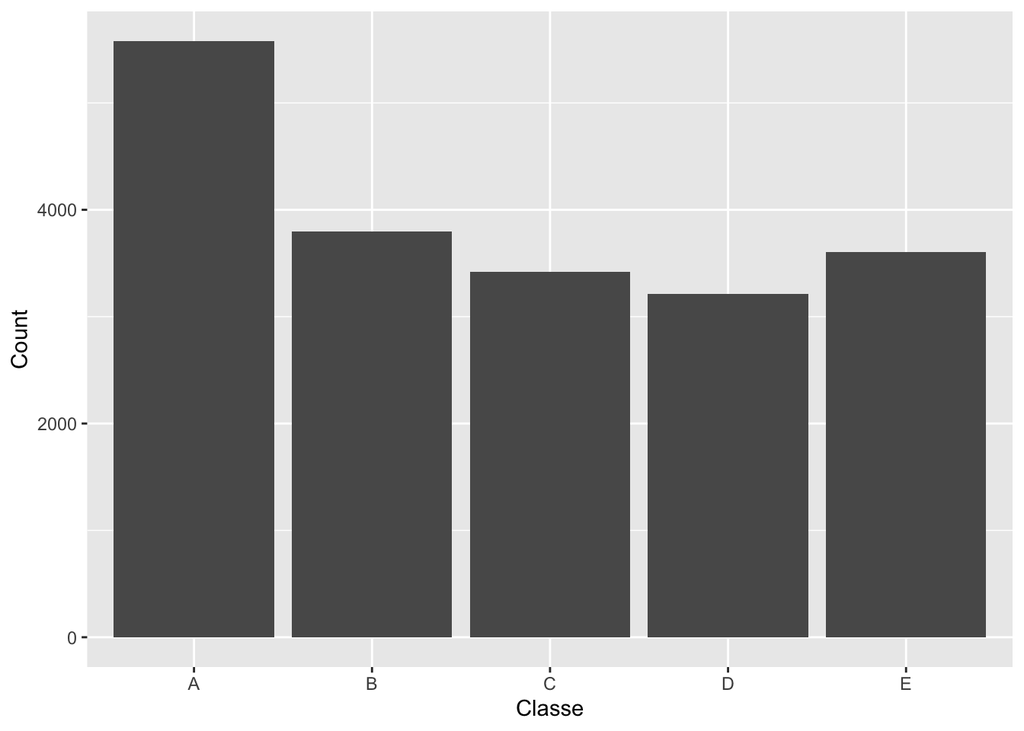

```r
g <- ggplot(training, aes(x = factor(classe)))
g <- g + geom_bar()
g <- g + labs(x = "Classe", y = "Count")
g
```

We end up looking at correlation between the remaining variables (keeping the classe column, that is not numerical, out of the analysis):

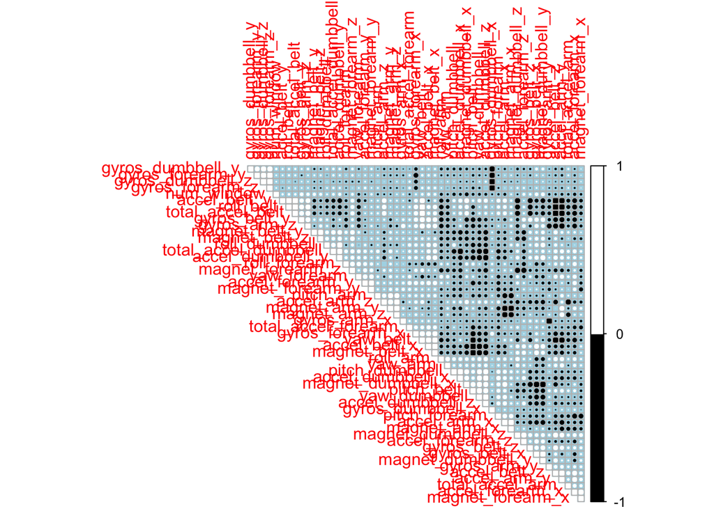

```r
corr_mtr <- cor(training[,-54])
corrplot(corr_mtr,
         order = "hclust",
         method = "circle",
         type = "upper",
         col = c("black", "white"),
         bg = "lightblue")
```

## Data Splitting

First, we set the seed to insure the reproducibility of our results. Then we’ll use the createDataPartition method to split our training dataset in two datasets, one for the actual training of our models, and the other one to check its validity:

```r
set.seed(32323)
inTrain <- createDataPartition(training$classe, p = 0.7, list = FALSE)
trainData <- training[inTrain, ]
testData <- training[-inTrain, ]
dim(trainData)
```

```
## [1] 13737    54
```

```r
dim(testData)
```

```
## [1] 5885   54
```

We’re gonna use these datasets with three different models: - Decision Trees - Random Forest - Generalized Boosted Method

## Decision Trees

We train a model with classe as outcome and every other remaining variable as predictor. The method parameter is set to ‘rpart’:

```r
mod_dt <- train(classe ~ .,
                method = "rpart",
                data = trainData)
```

Let’s show the resulting DT with the function fancyRpartPlot, from the rattle library:

[figure not shown]

```r
fancyRpartPlot(mod_dt$finalModel)
```

Now we’ll make the predictions on testData with this model and we’ll keep them in acc_dt:

```r
pred_dt <- predict(mod_dt, newdata = testData)
acc_dt <- as.numeric(confusionMatrix(pred_dt, testData$classe)$overall[1])
```

Finally, let’s see the whole confusion matrix:

```r
confusionMatrix(pred_dt, testData$classe)
```

```
## Confusion Matrix and Statistics
##
##           Reference
## Prediction    A    B    C    D    E
##          A 1378  241  118  259  241
##          B   77  559   81  247  181
##          C  213  339  827  458  183
##          D    0    0    0    0    0
##          E    6    0    0    0  477
##
## Overall Statistics
##
##                Accuracy : 0.5507
##                  95% CI : (0.5379, 0.5635)
##     No Information Rate : 0.2845
##     P-Value [Acc > NIR] : < 2.2e-16
##
##                   Kappa : 0.4235
##
##  Mcnemar's Test P-Value : NA
##
## Statistics by Class:
##
##                      Class: A Class: B Class: C Class: D Class: E
## Sensitivity            0.8232  0.49078   0.8060   0.0000  0.44085
## Specificity            0.7960  0.87653   0.7545   1.0000  0.99875
## Pos Pred Value         0.6160  0.48821   0.4094      NaN  0.98758
## Neg Pred Value         0.9189  0.87764   0.9485   0.8362  0.88800
## Prevalence             0.2845  0.19354   0.1743   0.1638  0.18386
## Detection Rate         0.2342  0.09499   0.1405   0.0000  0.08105
## Detection Prevalence   0.3801  0.19456   0.3432   0.0000  0.08207
## Balanced Accuracy      0.8096  0.68365   0.7803   0.5000  0.71980
```

## Random Forest

We train a new model, still with classe as outcome and every other remaining variable as predictor. The method parameter is this time set to ‘rf’:

```r
mod_rf <- train(classe ~ .,
                method = "rf",
                data = trainData,
                trControl = trainControl(method="cv", number=5, search="grid"),
                allowParallel = T)
```

Again, we’ll make the predictions on testData with this model and we’ll keep them in acc_rf:

```r
pred_rf <- predict(mod_rf, newdata = testData)
acc_rf <- as.numeric(confusionMatrix(pred_rf, testData$classe)$overall[1])
```

Finally, let’s take a look at the whole confusion matrix:

```r
confusionMatrix(pred_rf, testData$classe)
```

```
## Confusion Matrix and Statistics
##
##           Reference
## Prediction    A    B    C    D    E
##          A 1673    2    0    0    0
##          B    0 1137    3    0    0
##          C    0    0 1023    5    0
##          D    0    0    0  959    3
##          E    1    0    0    0 1079
##
## Overall Statistics
##
##                Accuracy : 0.9976
##                  95% CI : (0.996, 0.9987)
##     No Information Rate : 0.2845
##     P-Value [Acc > NIR] : < 2.2e-16
##
##                   Kappa : 0.997
##
##  Mcnemar's Test P-Value : NA
##
## Statistics by Class:
##
##                      Class: A Class: B Class: C Class: D Class: E
## Sensitivity            0.9994   0.9982   0.9971   0.9948   0.9972
## Specificity            0.9995   0.9994   0.9990   0.9994   0.9998
## Pos Pred Value         0.9988   0.9974   0.9951   0.9969   0.9991
## Neg Pred Value         0.9998   0.9996   0.9994   0.9990   0.9994
## Prevalence             0.2845   0.1935   0.1743   0.1638   0.1839
## Detection Rate         0.2843   0.1932   0.1738   0.1630   0.1833
## Detection Prevalence   0.2846   0.1937   0.1747   0.1635   0.1835
## Balanced Accuracy      0.9995   0.9988   0.9980   0.9971   0.9985
```

## Generalized Boosted Method

We train a third model, with classe as outcome and every other remaining variable as predictor. The method parameter is set to ‘gbm’:

```r
mod_gbm <- train(classe ~ .,
                 method = "gbm",
                 data = trainData)
```

For the third time, we’ll make the predictions on testData with this model and we’ll keep them in acc_gbm:

```r
pred_gbm <- predict(mod_gbm, newdata = testData)
acc_gbm <- as.numeric(confusionMatrix(pred_gbm, testData$classe)$overall[1])
```

While the whole confusion matrix is:

```r
confusionMatrix(pred_gbm, testData$classe)
```

```
## Confusion Matrix and Statistics
##
##           Reference
## Prediction    A    B    C    D    E
##          A 1670   11    0    0    0
##          B    4 1113   10    4    5
##          C    0   11 1016    9    1
##          D    0    4    0  951   19
##          E    0    0    0    0 1057
##
## Overall Statistics
##
##                Accuracy : 0.9867
##                  95% CI : (0.9835, 0.9895)
##     No Information Rate : 0.2845
##     P-Value [Acc > NIR] : < 2.2e-16
##
##                   Kappa : 0.9832
##
##  Mcnemar's Test P-Value : NA
##
## Statistics by Class:
##
##                      Class: A Class: B Class: C Class: D Class: E
## Sensitivity            0.9976   0.9772   0.9903   0.9865   0.9769
## Specificity            0.9974   0.9952   0.9957   0.9953   1.0000
## Pos Pred Value         0.9935   0.9798   0.9797   0.9764   1.0000
## Neg Pred Value         0.9990   0.9945   0.9979   0.9974   0.9948
## Prevalence             0.2845   0.1935   0.1743   0.1638   0.1839
## Detection Rate         0.2838   0.1891   0.1726   0.1616   0.1796
## Detection Prevalence   0.2856   0.1930   0.1762   0.1655   0.1796
## Balanced Accuracy      0.9975   0.9862   0.9930   0.9909   0.9884
```

## Applying our best model to the validating dataset

```r
accuracies <- data.frame(Method = c('Decision Trees', 'Random Forest', 'Generalized Boosted Method'),
                         Accuracy = c(acc_dt, acc_rf, acc_gbm))
```

Second, let’s check the winner:

```r
accuracies
```

```
##                       Method  Accuracy
## 1             Decision Trees 0.5507222
## 2              Random Forest 0.9976211
## 3 Generalized Boosted Method 0.9867460
```

The winner is Random Forest that reaches almost 100% of accuracy. To finish, we use the winning method to train a model on the whole dataset. Then, we use this model to produce our predictions on validating:

```r
mod_rf_whole <- train(classe ~ .,
                      method = "rf",
                      data = training,
                      allowParallel = T)
```

```r
predict(mod_rf_whole, validating)
```

```
##  [1] B A B A A E D B A A B C B A E E A B B B
## Levels: A B C D E
```

We got our predictions. Thank you.